# Project 04: Movielens Dataset Analysis

```python
import pandas as pd
import numpy as np
import matplotlib.pyplot as plt
import seaborn as sns
%matplotlib inline
```

```python
import warnings
warnings.simplefilter("ignore")
```

## Data acquisition of the movielens dataset

- users dataset
- rating dataset
- movies dataset

```python
User_df=pd.read_csv('E:/Datasets/Project4_Movielens/users.dat',sep='::',names = ['UserID','Gender','Age','Occupation','Zip-code'],header=None,engine='python')
Movies_df=pd.read_csv('E:/Datasets/Project4_Movielens/movies.dat',sep='::',names = ['MovieID','Title','Genres'],header=None,engine='python')
Rating_df=pd.read_csv('E:/Datasets/Project4_Movielens/ratings.dat',sep='::',names = ['UserID','MovieID','Rating','Timestamp'],header=None,engine='python')
```

## Exploratory Data Analysis (EDA)

#### Findings shapes of dataset imported and visualizing headers

```python
print('Shape of User Dataframe is', User_df.shape, 'Shape of Movies Dataframe is', Movies_df.shape, 'Shape of Ratings Dataframe is',Rating_df.shape)
```

```
Shape of User Dataframe is (6040, 5) Shape of Movies Dataframe is (3883, 3) Shape of Ratings Dataframe is (1000209, 4)
```

```python
User_df.head()
```

|  | UserID | Gender | Age | Occupation | Zip-code |
| --- | --- | --- | --- | --- | --- |
| 0 | 1 | F | 1 | 10 | 48067 |
| 1 | 2 | M | 56 | 16 | 70072 |
| 2 | 3 | M | 25 | 15 | 55117 |
| 3 | 4 | M | 45 | 7 | 02460 |
| 4 | 5 | M | 25 | 20 | 55455 |

```python
Movies_df.head()
```

|  | MovieID | Title | Genres |
| --- | --- | --- | --- |
| 0 | 1 | Toy Story (1995) | Animation\|Children's\|Comedy |
| 1 | 2 | Jumanji (1995) | Adventure\|Children's\|Fantasy |
| 2 | 3 | Grumpier Old Men (1995) | Comedy\|Romance |
| 3 | 4 | Waiting to Exhale (1995) | Comedy\|Drama |
| 4 | 5 | Father of the Bride Part II (1995) | Comedy |

```python
Rating_df.head()
```

|  | UserID | MovieID | Rating | Timestamp |
| --- | --- | --- | --- | --- |
| 0 | 1 | 1193 | 5 | 978300760 |
| 1 | 1 | 661 | 3 | 978302109 |
| 2 | 1 | 914 | 3 | 978301968 |
| 3 | 1 | 3408 | 4 | 978300275 |
| 4 | 1 | 2355 | 5 | 978824291 |

##### Merging Data into Combined Dataset

```python
# Merge ratings data to Movies data
Rating_movies=pd.merge(Rating_df,Movies_df,on=['MovieID'])
# merge Rating_Movie dataset with UserID
Total_df=pd.merge(Rating_movies,User_df,on=['UserID'])
print('Shape of Combined Dataset is {}'.format(Total_df.shape))
```

```
Shape of Combined Dataset is (1000209, 10)
```

```python
print('Top 5 Rows of Combined dataset')
print(Total_df.head())
```

```
Top 5 Rows of Combined dataset
   UserID  MovieID  Rating  Timestamp                                   Title  \
0       1     1193       5  978300760  One Flew Over the Cuckoo's Nest (1975)
1       1      661       3  978302109        James and the Giant Peach (1996)
2       1      914       3  978301968                     My Fair Lady (1964)
3       1     3408       4  978300275                  Erin Brockovich (2000)
4       1     2355       5  978824291                    Bug's Life, A (1998)

                         Genres Gender  Age  Occupation Zip-code
0                         Drama      F    1          10    48067
1  Animation|Children's|Musical      F    1          10    48067
2               Musical|Romance      F    1          10    48067
3                         Drama      F    1          10    48067
4   Animation|Children's|Comedy      F    1          10    48067
```

```python
# To look wheather there is a null value in Dataset or not.
Total_df.isnull().sum()
```

```
UserID        0
MovieID       0
Rating        0
Timestamp     0
Title         0
Genres        0
Gender        0
Age           0
Occupation    0
Zip-code      0
dtype: int64
```

#### There is no null value in our Combined dataset. Now we can proceed with further visulaization and analysis

## Lets Perform below EDA for dataset

1. Visualize user age distribution
2. Visualize overall rating by users
3. Find and visualize the user rating of the movie “Toy Story”
4. Find and visualize the viewership of the movie “Toy Story” by age group
5. Find and visualize the top 25 movies by viewership rating
6. Find the rating for a particular user of user id = 2696
7. Visualize the rating data by user of user id = 2696

### 1. Visualize user age distribution

Below are the age different age group and their labels:

- 1: "Under 18"
- 18: "18-24"
- 25: "25-34"
- 35: "35-44"
- 45: "45-49"
- 50: "50-55"
- 56: "56+"

```python
print('Total unique age groups are', len((Total_df['Age'].unique())))
print('and that are',Total_df['Age'].unique())
```

```
Total unique age groups are 7
and that are [ 1 56 25 50 18 45 35]
```

```python
#Frequency of different age groups in user data
Age_freq=pd.DataFrame(Total_df['Age'].value_counts())
Age_freq.reset_index(inplace=True)
Age_freq.columns=['Age_group','Counts']
Age_freq
```

|  | Age_group | Counts |
| --- | --- | --- |
| 0 | 25 | 395556 |
| 1 | 35 | 199003 |
| 2 | 18 | 183536 |
| 3 | 45 | 83633 |
| 4 | 50 | 72490 |
| 5 | 56 | 38780 |
| 6 | 1 | 27211 |

##### Lets Plot above Frequency of Different age groups using different Libraries:

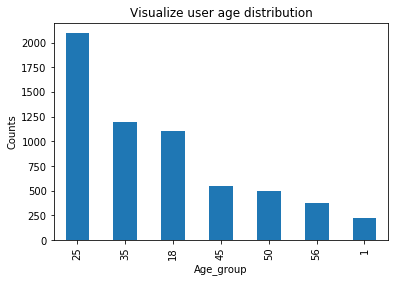

```python
#Using Pandas plotting
User_df['Age'].value_counts().plot(kind='bar')
plt.title('Visualize user age distribution')
plt.xlabel('Age_group')
plt.ylabel('Counts')
plt.show()
```

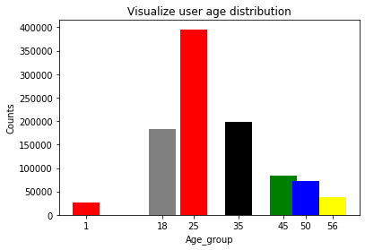

```python
#Using matplotlib
plt.figure()
plt.bar(Age_freq['Age_group'],Age_freq['Counts'],width=6, color=['red','black','grey','green','blue','yellow'])
plt.title('Visualize user age distribution')
plt.xlabel('Age_group')
plt.ylabel('Counts')
plt.xticks([1,18,25,35,45,50,56])
plt.show()
```

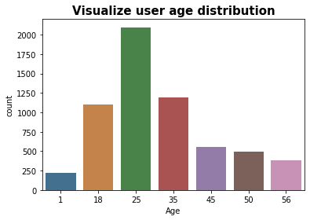

```python
# Using countplot from Seaborn library
sns.countplot(User_df['Age'],saturation=0.5).set_title('Visualize user age distribution',fontdict={'fontsize':15,'fontweight':'heavy'})
plt.show()
```

*Interpretation*: From Above Frequency Table and Count plot we came to conclusion that *Maximum user are of age group - "25-34"*

### 2. Visualize overall rating by users

```python
Grouped_UserID=Total_df.groupby('UserID')['Rating'].agg([('Count_Rating','count')])
print(Grouped_UserID.head())
```

```
        Count_Rating
UserID
1                 53
2                129
3                 51
4                 21
5                198
```

```python
print(Grouped_UserID.columns)
```

```
Index(['Count_Rating'], dtype='object')
```

```python
# Finding frequency Table for Viewship Rating
print(Total_df['Rating'].value_counts())
```

```
4    348971
3    261197
5    226310
2    107557
1     56174
Name: Rating, dtype: int64
```

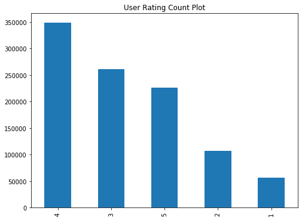

```python
#Ploting Above frequencies of User Rating
plt.figure(figsize=(8,6))
Rating_df['Rating'].value_counts().plot(kind='bar')
plt.title('User Rating Count Plot')
plt.show()
```

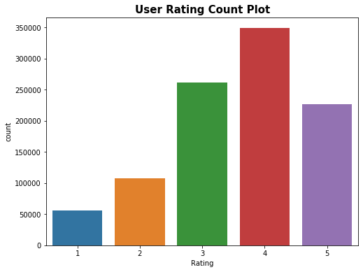

```python
# For more attractive plot lets plot using seaborn library
plt.figure(figsize=(8,6))
sns.countplot(Total_df['Rating'])
plt.title('User Rating Count Plot',fontdict={'fontsize':15,'fontweight':'heavy'})
plt.show()
```

**Interpretation** : View have given *4 rating to maximum of the movies*

### 3. Find and visualize the user rating of the movie “Toy Story”

```python
# To visualize the User Rating of movie 'Toy Story' lets groupby Combined Dataset on Title columns
Title_group=Total_df.groupby(['Title'])
Toy_story=Title_group.get_group('Toy Story (1995)')
pd.crosstab(Toy_story['Rating'] ,Toy_story['Title'])
```

| Title Rating | Toy Story (1995) |
| --- | --- |
| 1 | 16 |
| 2 | 61 |
| 3 | 345 |
| 4 | 835 |
| 5 | 820 |

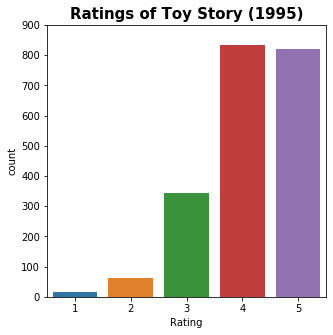

```python
# Ploting above frequency Table
plt.figure(figsize=(5,5))
sns.countplot(Toy_story['Rating'],linewidth=5).set_title("Ratings of Toy Story (1995)",fontdict={'fontsize':15,'fontweight':'heavy'})
plt.ylim(0,900)
plt.show()
```

**Interpretation** : Toy story (1995) has been given rating as below :

- 1 : 16
- 2 : 61
- 3 : 345
- 4 : 835
- 5 : 820

### 4. Find and visualize the viewership of the movie “Toy Story” by age group

```python
# Viewership of Movie "Toy Story" by age group can be visualized by frequency of Toy_story dataset w.r.t Age
Toy_story['Age'].value_counts()
```

```
25    790
18    448
35    423
45    143
1     112
50    108
56     53
Name: Age, dtype: int64
```

```python
# Finding Crosstab for more clear visual
Tiltle_Group=Total_df.groupby('Title')
Toy_story=Tiltle_Group.get_group('Toy Story (1995)')
print(pd.crosstab(Toy_story['Age'],Toy_story['Title']))
```

```
Title  Toy Story (1995)
Age
1                   112
18                  448
25                  790
35                  423
45                  143
50                  108
56                   53
```

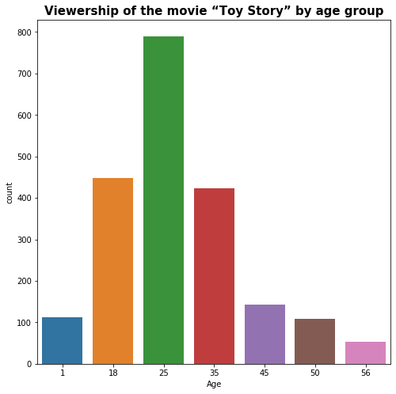

```python
plt.figure(figsize=(8,8))
sns.countplot(Toy_story['Age'])
plt.title("Viewership of the movie “Toy Story” by age group",fontdict={'fontsize':15,'fontweight':'heavy'})
plt.show()
```

**Interpretation** : Above Count plot concludes that *Viwer for "Toy Story" are maximum of Age group 25("25-34")*

### 5. visualize the top 25 movies by viewership rating

```python
# Grouping Dataset w.r.t. to Title and Rating
new_grouped=Total_df.groupby('Title')['Rating'].mean()
```

```python
(new_grouped.sort_values()[-25:])
```

```
Title
Hour of the Pig, The (1993)                                            4.500000
Inheritors, The (Die Siebtelbauern) (1998)                             4.500000
Mamma Roma (1962)                                                      4.500000
Dangerous Game (1993)                                                  4.500000
Wrong Trousers, The (1993)                                             4.507937
Schindler's List (1993)                                                4.510417
Usual Suspects, The (1995)                                             4.517106
Close Shave, A (1995)                                                  4.520548
Godfather, The (1972)                                                  4.524966
Shawshank Redemption, The (1994)                                       4.554558
Seven Samurai (The Magnificent Seven) (Shichinin no samurai) (1954)    4.560510
Sanjuro (1962)                                                         4.608696
Apple, The (Sib) (1998)                                                4.666667
Lamerica (1994)                                                        4.750000
I Am Cuba (Soy Cuba/Ya Kuba) (1964)                                    4.800000
Schlafes Bruder (Brother of Sleep) (1995)                              5.000000
One Little Indian (1973)                                               5.000000
Baby, The (1973)                                                       5.000000
Bittersweet Motel (2000)                                               5.000000
Song of Freedom (1936)                                                 5.000000
Follow the Bitch (1998)                                                5.000000
Smashing Time (1967)                                                   5.000000
Ulysses (Ulisse) (1954)                                                5.000000
Lured (1947)                                                           5.000000
Gate of Heavenly Peace, The (1995)                                     5.000000
Name: Rating, dtype: float64
```

```python
# Sorting Value and Find Top 25 Movies with highest average rating

Top_movies=pd.DataFrame(new_grouped.sort_values()[-25:])
Top_movies.reset_index(inplace=True)
Top_movies.columns=['Title','Average_rating']
```

```python
Top_movies
```

|  | Title | Average_rating |
| --- | --- | --- |
| 0 | Hour of the Pig, The (1993) | 4.500000 |
| 1 | Inheritors, The (Die Siebtelbauern) (1998) | 4.500000 |
| 2 | Mamma Roma (1962) | 4.500000 |
| 3 | Dangerous Game (1993) | 4.500000 |
| 4 | Wrong Trousers, The (1993) | 4.507937 |
| 5 | Schindler's List (1993) | 4.510417 |
| 6 | Usual Suspects, The (1995) | 4.517106 |
| 7 | Close Shave, A (1995) | 4.520548 |
| 8 | Godfather, The (1972) | 4.524966 |
| 9 | Shawshank Redemption, The (1994) | 4.554558 |
| 10 | Seven Samurai (The Magnificent Seven) (Shichin... | 4.560510 |
| 11 | Sanjuro (1962) | 4.608696 |
| 12 | Apple, The (Sib) (1998) | 4.666667 |
| 13 | Lamerica (1994) | 4.750000 |
| 14 | I Am Cuba (Soy Cuba/Ya Kuba) (1964) | 4.800000 |
| 15 | Schlafes Bruder (Brother of Sleep) (1995) | 5.000000 |
| 16 | One Little Indian (1973) | 5.000000 |
| 17 | Baby, The (1973) | 5.000000 |
| 18 | Bittersweet Motel (2000) | 5.000000 |
| 19 | Song of Freedom (1936) | 5.000000 |
| 20 | Follow the Bitch (1998) | 5.000000 |
| 21 | Smashing Time (1967) | 5.000000 |
| 22 | Ulysses (Ulisse) (1954) | 5.000000 |
| 23 | Lured (1947) | 5.000000 |
| 24 | Gate of Heavenly Peace, The (1995) | 5.000000 |

```python
print("Top 25 Movies by viewship rating are {}".format(Top_movies['Title'].unique()))
```

```
Top 25 Movies by viewship rating are ['Hour of the Pig, The (1993)'
 'Inheritors, The (Die Siebtelbauern) (1998)' 'Mamma Roma (1962)'
 'Dangerous Game (1993)' 'Wrong Trousers, The (1993)'
 "Schindler's List (1993)" 'Usual Suspects, The (1995)'
 'Close Shave, A (1995)' 'Godfather, The (1972)'
 'Shawshank Redemption, The (1994)'
 'Seven Samurai (The Magnificent Seven) (Shichinin no samurai) (1954)'
 'Sanjuro (1962)' 'Apple, The (Sib) (1998)' 'Lamerica (1994)'
 'I Am Cuba (Soy Cuba/Ya Kuba) (1964)'
 'Schlafes Bruder (Brother of Sleep) (1995)' 'One Little Indian (1973)'
 'Baby, The (1973)' 'Bittersweet Motel (2000)' 'Song of Freedom (1936)'
 'Follow the Bitch (1998)' 'Smashing Time (1967)'
 'Ulysses (Ulisse) (1954)' 'Lured (1947)'
 'Gate of Heavenly Peace, The (1995)']
```

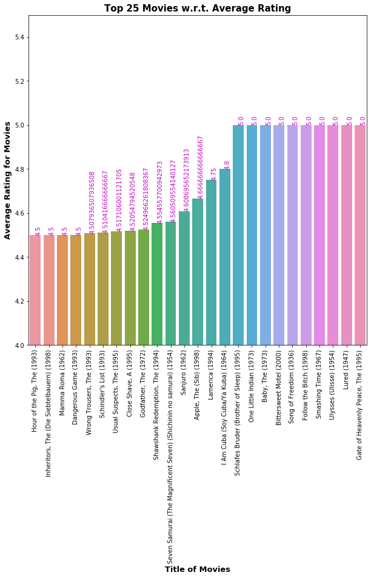

```python
# Lets plot Top 25 Movies w.r.t to Average Rating
plt.figure(figsize=(10,10))
ax=sns.barplot(Top_movies['Title'],Top_movies['Average_rating'])
plt.title('Top 25 Movies w.r.t. Average Rating',fontdict={'fontsize':15,'fontweight':'heavy'})
plt.xlabel('Title of Movies',fontdict={'fontsize':13,'fontweight':'bold'})
plt.ylabel('Average Rating for Movies',fontdict={'fontsize':13,'fontweight':'bold'})
plt.xticks(rotation=90)
plt.ylim(4,5.5)
for i, v in enumerate(Top_movies['Average_rating'].iteritems()):
    ax.text(i ,v[1], "{:,}".format(v[1]), color='m', va ='bottom', rotation=90)
plt.show()
```

*Interpretaion* : Above bar plot show Top 25 Movies by User Rating

### 6. Find the rating for a particular user of user id = 2696

```python
User_grouped=Total_df.groupby('UserID')
user_2696=User_grouped.get_group(2696)[['Rating','Title']]
print("Rating For Different Movies by User id =2696")
print(user_2696)
```

```
Rating For Different Movies by User id =2696
        Rating                                           Title
953847       2                       Back to the Future (1985)
953848       3               E.T. the Extra-Terrestrial (1982)
953849       4                        L.A. Confidential (1997)
953850       5                                Lone Star (1996)
953851       1                                      JFK (1991)
953852       4                 Talented Mr. Ripley, The (1999)
953853       4  Midnight in the Garden of Good and Evil (1997)
953854       3                                 Cop Land (1997)
953855       4                                 Palmetto (1998)
953856       4                        Perfect Murder, A (1998)
953857       4                                Game, The (1997)
953858       2          I Know What You Did Last Summer (1997)
953859       4                    Devil's Advocate, The (1997)
953860       4                                   Psycho (1998)
953861       4                              Wild Things (1998)
953862       4                           Basic Instinct (1992)
953863       1                              Lake Placid (1999)
953864       4                             Shining, The (1980)
953865       2    I Still Know What You Did Last Summer (1998)
953866       3                              Client, The (1994)
```

### 7. Visualize the rating data by user of user id = 2696

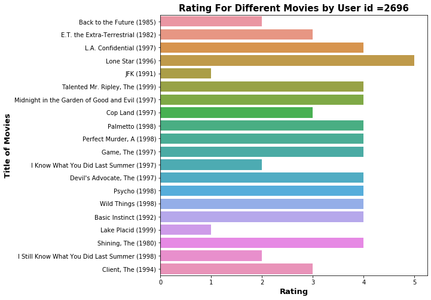

```python
plt.figure(figsize=(8,8))
ax=sns.barplot(user_2696['Rating'],user_2696['Title'])
plt.title("Rating For Different Movies by User id =2696",fontdict={'fontsize':15,'fontweight':'heavy'})
plt.ylabel('Title of Movies',fontdict={'fontsize':13,'fontweight':'bold'})
plt.xlabel('Rating',fontdict={'fontsize':13,'fontweight':'bold'})

plt.show()
```

**Interpretation** : User id 2696 gave highest rating i.e. "5" to only Movie "Lone Star (1996)".

## Feature Engineering and Visualization for Genres Attribute

```python
Total_df.head()
```

|  | UserID | MovieID | Rating | Timestamp | Title | Genres | Gender | Age | Occupation | Zip-code |
| --- | --- | --- | --- | --- | --- | --- | --- | --- | --- | --- |
| 0 | 1 | 1193 | 5 | 978300760 | One Flew Over the Cuckoo's Nest (1975) | Drama | F | 1 | 10 | 48067 |
| 1 | 1 | 661 | 3 | 978302109 | James and the Giant Peach (1996) | Animation\|Children's\|Musical | F | 1 | 10 | 48067 |
| 2 | 1 | 914 | 3 | 978301968 | My Fair Lady (1964) | Musical\|Romance | F | 1 | 10 | 48067 |
| 3 | 1 | 3408 | 4 | 978300275 | Erin Brockovich (2000) | Drama | F | 1 | 10 | 48067 |
| 4 | 1 | 2355 | 5 | 978824291 | Bug's Life, A (1998) | Animation\|Children's\|Comedy | F | 1 | 10 | 48067 |

```python
Total_df['Genres']=Total_df['Genres'].str.split("|")
```

```python
Total_df.head()
```

|  | UserID | MovieID | Rating | Timestamp | Title | Genres | Gender | Age | Occupation | Zip-code |
| --- | --- | --- | --- | --- | --- | --- | --- | --- | --- | --- |
| 0 | 1 | 1193 | 5 | 978300760 | One Flew Over the Cuckoo's Nest (1975) | [Drama] | F | 1 | 10 | 48067 |
| 1 | 1 | 661 | 3 | 978302109 | James and the Giant Peach (1996) | [Animation, Children's, Musical] | F | 1 | 10 | 48067 |
| 2 | 1 | 914 | 3 | 978301968 | My Fair Lady (1964) | [Musical, Romance] | F | 1 | 10 | 48067 |
| 3 | 1 | 3408 | 4 | 978300275 | Erin Brockovich (2000) | [Drama] | F | 1 | 10 | 48067 |
| 4 | 1 | 2355 | 5 | 978824291 | Bug's Life, A (1998) | [Animation, Children's, Comedy] | F | 1 | 10 | 48067 |

```python
df_5k=Total_df[:5000]
len(df_5k)
```

```
5000
```

```python
df_5k.head()
```

|  | UserID | MovieID | Rating | Timestamp | Title | Genres | Gender | Age | Occupation | Zip-code |
| --- | --- | --- | --- | --- | --- | --- | --- | --- | --- | --- |
| 0 | 1 | 1193 | 5 | 978300760 | One Flew Over the Cuckoo's Nest (1975) | [Drama] | F | 1 | 10 | 48067 |
| 1 | 1 | 661 | 3 | 978302109 | James and the Giant Peach (1996) | [Animation, Children's, Musical] | F | 1 | 10 | 48067 |
| 2 | 1 | 914 | 3 | 978301968 | My Fair Lady (1964) | [Musical, Romance] | F | 1 | 10 | 48067 |
| 3 | 1 | 3408 | 4 | 978300275 | Erin Brockovich (2000) | [Drama] | F | 1 | 10 | 48067 |
| 4 | 1 | 2355 | 5 | 978824291 | Bug's Life, A (1998) | [Animation, Children's, Comedy] | F | 1 | 10 | 48067 |

```python
def all_genres():
    x=[]
    for i in range(len(df_5k)):
        x+=df_5k.Genres[i]
    return(x)
```

```python
x=all_genres()
```

```python
Genres=list(set(x))
```

```python
print(Genres)
```

```
['Documentary', 'Thriller', 'Musical', 'Crime', 'Mystery', 'Horror', 'Film-Noir', 'Drama', 'Romance', "Children's", 'Comedy', 'Animation', 'Adventure', 'Action', 'Fantasy', 'Sci-Fi', 'War', 'Western']
```

```python
unique_genres = pd.Series(Genres)
```

```python
a={}
for i in Genres:
    a[i]=x.count(i)
```

```python
a=pd.DataFrame.from_dict(a,orient='index')
a.reset_index(inplace=True)
a.columns=['Genres','Count']
a=a.sort_values(['Count'],ascending =False)
```

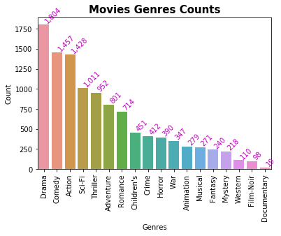

```python
ax=sns.barplot(a['Genres'],a['Count'])
plt.title("Movies Genres Counts",fontdict={'fontsize':15,'fontweight':'heavy'})
plt.xticks(rotation=90)
for i, v in enumerate(a["Count"].iteritems()):
    ax.text(i ,v[1], "{:,}".format(v[1]), color='m', va ='bottom',
    rotation=45)

plt.show()
```

```python
Genres_Series=pd.Series(Genres)
Genres_Series
```

```
0     Documentary
1        Thriller
2         Musical
3           Crime
4         Mystery
5          Horror
6       Film-Noir
7           Drama
8         Romance
9      Children's
10         Comedy
11      Animation
12      Adventure
13         Action
14        Fantasy
15         Sci-Fi
16            War
17        Western
dtype: object
```

```python
df = pd.DataFrame()
for row in df_5k.Genres:
    a = Genres_Series.isin(row) #is in method of series can be applied
    df = df.append(a, ignore_index = True)
```

```python
df.columns=Genres_Series
```

```python
df_5k=pd.concat((df_5k,df),axis=1)
```

```python
df_5k.shape
```

```
(5000, 28)
```

```python
df_5k.columns
```

```
Index(['UserID', 'MovieID', 'Rating', 'Timestamp', 'Title', 'Genres', 'Gender',
       'Age', 'Occupation', 'Zip-code', 'Documentary', 'Thriller', 'Musical',
       'Crime', 'Mystery', 'Horror', 'Film-Noir', 'Drama', 'Romance',
       'Children's', 'Comedy', 'Animation', 'Adventure', 'Action', 'Fantasy',
       'Sci-Fi', 'War', 'Western'],
      dtype='object')
```

```python
df_5k.drop(['UserID','MovieID', 'Timestamp','Zip-code','Title'],axis=1,inplace=True)
```

```python
df_5k.columns
```

```
Index(['Rating', 'Genres', 'Gender', 'Age', 'Occupation', 'Documentary',
       'Thriller', 'Musical', 'Crime', 'Mystery', 'Horror', 'Film-Noir',
       'Drama', 'Romance', 'Children's', 'Comedy', 'Animation', 'Adventure',
       'Action', 'Fantasy', 'Sci-Fi', 'War', 'Western'],
      dtype='object')
```

```python
df_5k.head()
```

|  | Rating | Genres | Gender | Age | Occupation | Documentary | Thriller | Musical | Crime | Mystery | ... | Romance | Children's | Comedy | Animation | Adventure | Action | Fantasy | Sci-Fi | War | Western |
| --- | --- | --- | --- | --- | --- | --- | --- | --- | --- | --- | --- | --- | --- | --- | --- | --- | --- | --- | --- | --- | --- |
| 0 | 5 | [Drama] | F | 1 | 10 | 0.0 | 0.0 | 0.0 | 0.0 | 0.0 | ... | 0.0 | 0.0 | 0.0 | 0.0 | 0.0 | 0.0 | 0.0 | 0.0 | 0.0 | 0.0 |
| 1 | 3 | [Animation, Children's, Musical] | F | 1 | 10 | 0.0 | 0.0 | 1.0 | 0.0 | 0.0 | ... | 0.0 | 1.0 | 0.0 | 1.0 | 0.0 | 0.0 | 0.0 | 0.0 | 0.0 | 0.0 |
| 2 | 3 | [Musical, Romance] | F | 1 | 10 | 0.0 | 0.0 | 1.0 | 0.0 | 0.0 | ... | 1.0 | 0.0 | 0.0 | 0.0 | 0.0 | 0.0 | 0.0 | 0.0 | 0.0 | 0.0 |
| 3 | 4 | [Drama] | F | 1 | 10 | 0.0 | 0.0 | 0.0 | 0.0 | 0.0 | ... | 0.0 | 0.0 | 0.0 | 0.0 | 0.0 | 0.0 | 0.0 | 0.0 | 0.0 | 0.0 |
| 4 | 5 | [Animation, Children's, Comedy] | F | 1 | 10 | 0.0 | 0.0 | 0.0 | 0.0 | 0.0 | ... | 0.0 | 1.0 | 1.0 | 1.0 | 0.0 | 0.0 | 0.0 | 0.0 | 0.0 | 0.0 |

5 rows × 23 columns

#### Performing One hot encoding on Occupation variable

Below mentioned are Occupation and their labels

- Occupation is chosen from the following choices:
- 0: "other" or not specified
- 1: "academic/educator"
- 2: "artist"
- 3: "clerical/admin"
- 4: "college/grad student"
- 5: "customer service"
- 6: "doctor/health care"
- 7: "executive/managerial"
- 8: "farmer"
- 9: "homemaker"
- 10: "K-12 student"
- 11: "lawyer"
- 12: "programmer"
- 13: "retired"
- 14: "sales/marketing"
- 15: "scientist"
- 16: "self-employed"
- 17: "technician/engineer"
- 18: "tradesman/craftsman"
- 19: "unemployed"
- 20: "writer"

```python
Occupations=["other","academic/educator","artist","clerical/admin","college/grad student",
            "customer service","doctor/health care","executive/managerial","farmer","homemaker",
             "K-12 student","lawyer","programmer","retired","sales/marketing","scientist","self-employed",
             "technician/engineer","tradesman/craftsman","unemployed","writer"]
len(Occupations)
```

```
21
```

```python
df_5k['Occupation']=df_5k['Occupation'].astype(str)
```

```python
def occupation():
    df_5k["others"]=df_5k['Occupation'].map(lambda d: 1 if d=='0' else 0)
    df_5k["academic/educator"]=df_5k['Occupation'].map(lambda d: 1 if d=='1' else 0)
    df_5k["artist"]=df_5k['Occupation'].map(lambda d: 1 if d=='2' else 0)
    df_5k["clerical/admin"]=df_5k['Occupation'].map(lambda d: 1 if d=='3' else 0)
    df_5k["college/grad student"]=df_5k['Occupation'].map(lambda d: 1 if d=='4' else 0)
    df_5k["customer service"]=df_5k['Occupation'].map(lambda d: 1 if d=='5' else 0)
    df_5k["doctor/health care"]=df_5k['Occupation'].map(lambda d: 1 if d=='6' else 0)
    df_5k["executivemanagerial"]=df_5k['Occupation'].map(lambda d: 1 if d=='7' else 0)
    df_5k["farmer"]=df_5k['Occupation'].map(lambda d: 1 if d=='8' else 0)
    df_5k["homemaker"]=df_5k['Occupation'].map(lambda d: 1 if d=='9' else 0)
    df_5k["K-12 student"]=df_5k['Occupation'].map(lambda d: 1 if d=='10' else 0)
    df_5k["lawyer"]=df_5k['Occupation'].map(lambda d: 1 if d=='11' else 0)
    df_5k["programmer"]=df_5k['Occupation'].map(lambda d: 1 if d=='12' else 0)
    df_5k["retired"]=df_5k['Occupation'].map(lambda d: 1 if d=='13' else 0)
    df_5k["sales/marketing"]=df_5k['Occupation'].map(lambda d: 1 if d=='14' else 0)
    df_5k["scientist"]=df_5k['Occupation'].map(lambda d: 1 if d=='15' else 0)
    df_5k["self-employed"]=df_5k['Occupation'].map(lambda d: 1 if d=='16' else 0)
    df_5k["technician/engineer"]=df_5k['Occupation'].map(lambda d: 1 if d=='17' else 0)
    df_5k["tradesman/craftsman"]=df_5k['Occupation'].map(lambda d: 1 if d=='18' else 0)
    df_5k["unemployed"]=df_5k['Occupation'].map(lambda d: 1 if d=='19' else 0)
    df_5k["writer"]=df_5k['Occupation'].map(lambda d: 1 if d=='20' else 0)

occupation()
```

```python
df_5k.columns
```

```
Index(['Rating', 'Genres', 'Gender', 'Age', 'Occupation', 'Documentary',
       'Thriller', 'Musical', 'Crime', 'Mystery', 'Horror', 'Film-Noir',
       'Drama', 'Romance', 'Children's', 'Comedy', 'Animation', 'Adventure',
       'Action', 'Fantasy', 'Sci-Fi', 'War', 'Western', 'others',
       'academic/educator', 'artist', 'clerical/admin', 'college/grad student',
       'customer service', 'doctor/health care', 'executivemanagerial',
       'farmer', 'homemaker', 'K-12 student', 'lawyer', 'programmer',
       'retired', 'sales/marketing', 'scientist', 'self-employed',
       'technician/engineer', 'tradesman/craftsman', 'unemployed', 'writer'],
      dtype='object')
```

```python
df_5k.drop(['Occupation','Genres'],axis=1,inplace=True)
```

#### Performing One hot encoding on Gender variable

```python
Gender_dummies=pd.get_dummies(df_5k['Gender'])
df_5k=pd.concat((df_5k,Gender_dummies),axis=1)
```

```python
df_5k.drop('Gender',axis=1,inplace=True)
```

```python
df_5k.columns
```

```
Index(['Rating', 'Age', 'Documentary', 'Thriller', 'Musical', 'Crime',
       'Mystery', 'Horror', 'Film-Noir', 'Drama', 'Romance', 'Children's',
       'Comedy', 'Animation', 'Adventure', 'Action', 'Fantasy', 'Sci-Fi',
       'War', 'Western', 'others', 'academic/educator', 'artist',
       'clerical/admin', 'college/grad student', 'customer service',
       'doctor/health care', 'executivemanagerial', 'farmer', 'homemaker',
       'K-12 student', 'lawyer', 'programmer', 'retired', 'sales/marketing',
       'scientist', 'self-employed', 'technician/engineer',
       'tradesman/craftsman', 'unemployed', 'writer', 'F', 'M'],
      dtype='object')
```

```python
df_5k.shape
```

```
(5000, 43)
```

```python
df_5k.dtypes
```

```
Rating                    int64
Age                       int64
Documentary             float64
Thriller                float64
Musical                 float64
Crime                   float64
Mystery                 float64
Horror                  float64
Film-Noir               float64
Drama                   float64
Romance                 float64
Children's              float64
Comedy                  float64
Animation               float64
Adventure               float64
Action                  float64
Fantasy                 float64
Sci-Fi                  float64
War                     float64
Western                 float64
others                    int64
academic/educator         int64
artist                    int64
clerical/admin            int64
college/grad student      int64
customer service          int64
doctor/health care        int64
executivemanagerial       int64
farmer                    int64
homemaker                 int64
K-12 student              int64
lawyer                    int64
programmer                int64
retired                   int64
sales/marketing           int64
scientist                 int64
self-employed             int64
technician/engineer       int64
tradesman/craftsman       int64
unemployed                int64
writer                    int64
F                         uint8
M                         uint8
dtype: object
```

## Performing Machine learning

```python
Target=df_5k['Rating']
X_data=df_5k.drop(['Rating'],axis=True)
```

```python
print(Target.shape)
print(X_data.shape)
```

```
(5000,)
(5000, 42)
```

```python
from sklearn.model_selection import train_test_split
X_test, X_train, Y_test, Y_train = train_test_split(X_data,Target,random_state=0)
```

```python
print(X_test.shape)
print(X_train.shape)
print(Y_test.shape)
print(Y_train.shape)
```

```
(3750, 42)
(1250, 42)
(3750,)
(1250,)
```

```python
# machine learning models
from sklearn.model_selection import train_test_split
from sklearn.linear_model import LogisticRegression
from sklearn.svm import SVC, LinearSVC
from sklearn.ensemble import RandomForestClassifier
from sklearn.neighbors import KNeighborsClassifier
from sklearn.naive_bayes import GaussianNB
from sklearn.linear_model import Perceptron
from sklearn.linear_model import SGDClassifier
from sklearn.tree import DecisionTreeClassifier
```

```python
from sklearn.metrics import accuracy_score
from sklearn.metrics import confusion_matrix
```

#### Using Multinomial Logistic Regression

```python
model = LogisticRegression(random_state=0, solver='lbfgs',multi_class='multinomial')
model.fit(X_train, Y_train)
predicted_train = model.predict(X_test)
true_value = Y_test
print("Train Accuracy {:.2%}".format(accuracy_score(true_value,predicted_train)))
```

```
Train Accuracy 42.11%
```

#### Using Support Vector machine

```python
model_svc=SVC()
model_svc.fit(X_train, Y_train)
SVC_predicted = model_svc.predict(X_test)
score=model_svc.score(X_test,Y_test)
print("Train Accuracy {:.2%}".format(accuracy_score(true_value,SVC_predicted)))
```

```
Train Accuracy 43.81%
```

#### Using K-Nearest neighbors

```python
knn = KNeighborsClassifier(n_neighbors = 10)
knn.fit(X_train, Y_train)
knn_predicted = knn.predict(X_test)
acc_knn = knn.score(X_test,Y_test)
print("Train Accuracy {:.2%}".format(accuracy_score(true_value,knn_predicted)))
print
```

```
Train Accuracy 40.03%
```

```
<function print>
```

#### Using Gaussian Naive Baiyes

```python
gaussian = GaussianNB()
gaussian.fit(X_train, Y_train)
GaussianNB_pred = gaussian.predict(X_test)
acc_gaussian = gaussian.score(X_test,Y_test) * 100
print("Train Accuracy {:.2%}".format(accuracy_score(true_value,GaussianNB_pred)))
print(acc_gaussian)
```

```
Train Accuracy 5.39%
5.386666666666667
```

#### Using Linear Support Vector Machine

```python
Linear_svc=LinearSVC()
Linear_svc.fit(X_train,Y_train)
Linear_svc_Pred=Linear_svc.predict(X_test)
print("Train Accuracy {:.2%}".format(accuracy_score(true_value,Linear_svc_Pred)))
```

```
Train Accuracy 39.68%
```

#### Using Decision Tree

```python
descisiontree=DecisionTreeClassifier()
descisiontree.fit(X_train,Y_train)
descisiontree_pred=descisiontree.predict(X_test)
print("Train Accuracy {:.2%}".format(accuracy_score(true_value,descisiontree_pred)))
```

```
Train Accuracy 36.29%
```

#### Using Random Forest Classifier

```python
Randomforest=RandomForestClassifier(n_estimators=100)
Randomforest.fit(X_train,Y_train)
Randomforest_pred=Randomforest.predict(X_test)
print("Train Accuracy {:.2%}".format(accuracy_score(true_value,Randomforest_pred)))
```

```
Train Accuracy 39.68%
```

```python
from sklearn.model_selection import GridSearchCV
```

```python
rfc_models = RandomForestClassifier()
rfc_params = {'n_estimators': [50,100],
                      'max_depth': [25,30],
                      'min_samples_leaf': 2,
                      'min_samples_split': [4,6,3]}

# Defining LR(logistic regression) model hyper-parameters
lr_models = LogisticRegression()
lr_params = {'C': [0.1, 0.01],
                     'tol': [0.001, 0.01],
                     'max_iter': [100, 200]}

dt_models = DecisionTreeClassifier()
dt_params = { 'max_depth': [25,30],
            'min_samples_leaf': [2],
            'min_samples_split': [4,6,3]}

knn_models = KNeighborsClassifier()
knn_params = {'n_neighbors':[5,15,30,50]}

grid = zip([lr_models,dt_models,knn_models],[lr_params,dt_params,knn_params])

best_clf = None
# perform grid search and select the model with best cv set scores
for model_pipeline, param in grid:
    temp = GridSearchCV(model_pipeline, param_grid=param, cv=3, n_jobs=1)
    temp.fit(X_train,Y_train)
    if best_clf is None:
        best_clf = temp
    else:
        if temp.best_score_ > best_clf.best_score_:
            best_clf = temp

print ("Best CV Score",best_clf.best_score_)
print ("Model Parameters",best_clf.best_params_)
```

```
Best CV Score 0.4104
Model Parameters {'n_neighbors': 15}
```